# Using a GRTS Design for Spawning Ground Surveys in the Newaukum River

Coho Salmon

Kevin See<sup>1,✉</sup>, and Lea Ronne<sup>1</sup>

July 11, 2022

<sup>1</sup> Washington Department of Fish & Wildlife

<sup>✉</sup> Correspondence: Kevin See <Kevin.See@dfw.wa.gov>

# 1 Goals

To determine the feasibility of shifting from an attempted census survey of the Coho Salmon spawning grounds in the Newaukum River to a **G**eneralized **R**andom-**T**esselation **S**tratified (GRTS) survey design (Stevens and Olsen 2003; Stevens and Olsen 2004). The current census design has proved extremely labor intensive over the last few years. This work could lead to a more feasible study design that allows for some flexibility in the amount of effort deployed.

# 2 Methods

## 2.1 Entire Index Frame

We focused on Coho index areas in the Newaukum. In 2019, 2020 and 2021, WDFW attempted to survey these areas on a weekly basis. By concentrating on the index areas, we ignored the reaches that were only surveyed once, near peak spawning. This removes the extrapolation techniques applied to those non-index reaches from this analysis (Figure 2.1). The index areas comprise about 80 miles of stream within the Newaukum.

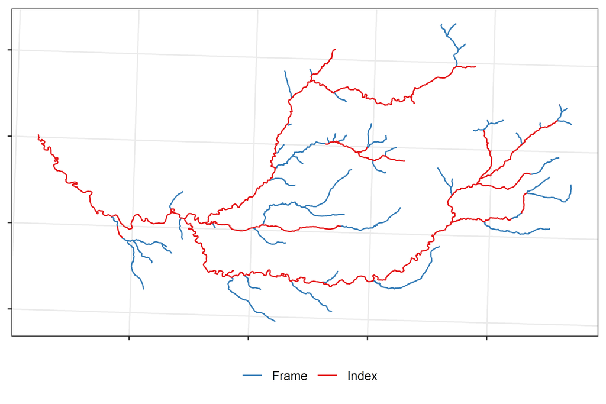

Figure 2.1: Map of the Newaukum River, showing the entire Coho Salmon spawning area in blue, and the index areas overlaid in red.

The initial design treated the entire index area as the GRTS frame, so points were drawn from this frame. We tested 16, 24, 32 and 40 GRTS sites, corresponding to surveying 20, 30, 40 and 50% of the entire index frame, assuming that each site would be a mile long reach. To construct the actual reaches, we strove to create a half mile buffer upstream and downstream of the GRTS point. If we were not able to extend the reach a half mile in one direction (e.g. hit the upstream extent of the frame, or the downstream end merged with a larger tributary), we extended the reach further in the other direction if possible. The final lengths of all created reaches was recorded.

We created a small (10 ft) buffer around each GRTS reach, and identified the redds from each year that fell within that buffer, and assumed those were the redds counted at that GRTS reach. Using the length of the reach, we converted the number of observed redds into redds / mi.

We focus on how well estimates of total redds from various GRTS-based designs compare with the observed total number of redds observed in the index areas in each of those three years (Figure 2.2).

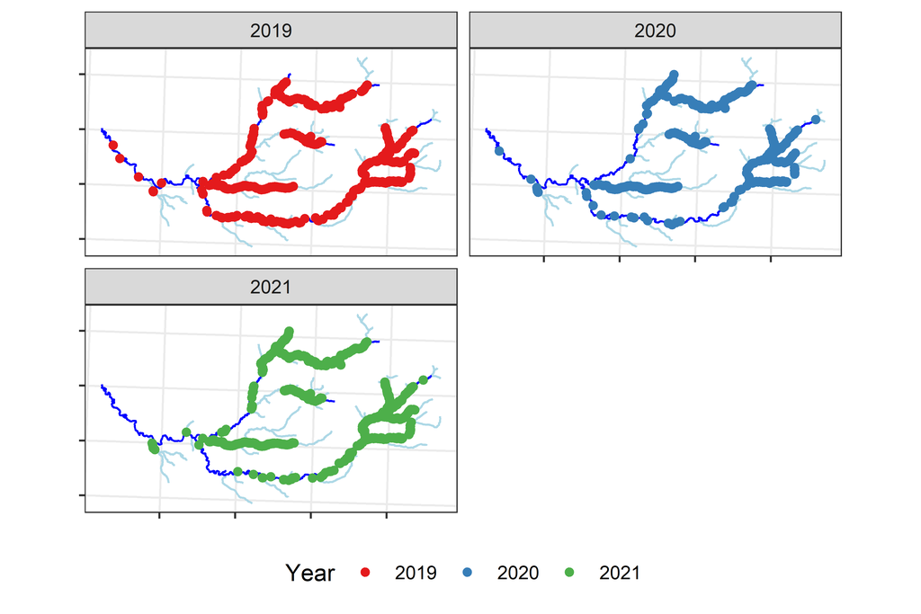

Figure 2.2: Map of the Newaukum River showing the location of all the redds identified in the index areas in each year. Light blue is the entire Coho spawning grounds, while darker blue indicates the index areas.

### 2.1.1 Example

Figure 2.3 shows some examples of GRTS designs.

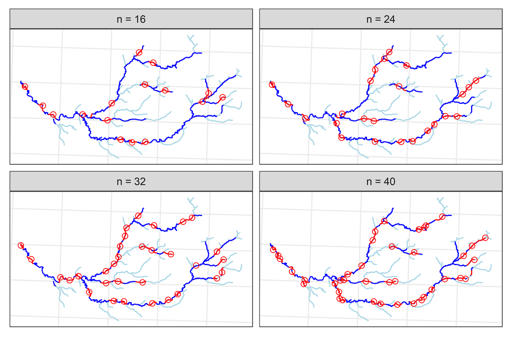

Figure 2.3: Example of a GRTS draw using various number of sites. Dark blue indicates the index areas. Red points are the GRTS points, and the red lines are the subsequent GRTS reaches.

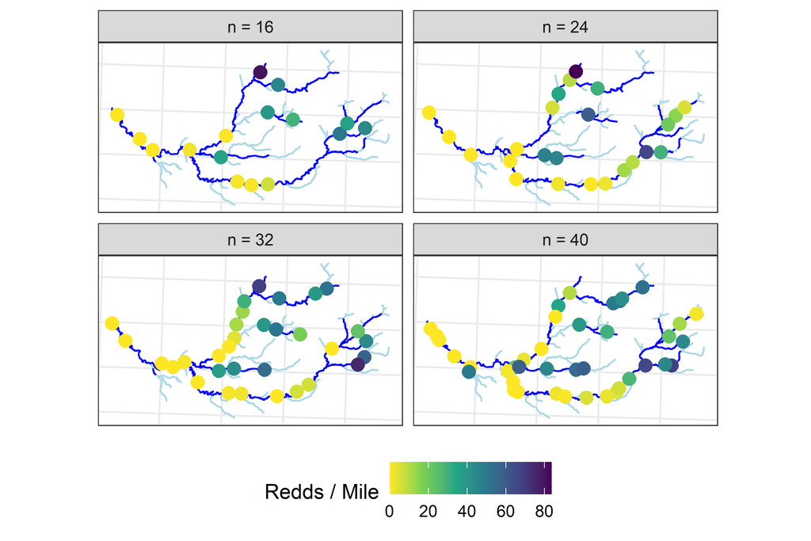

Figure 2.4: Using the example GRTS draws, these figures show the observed redd densities at those GRTS reaches in 2021.